# Johns Hopkins Covid Analysis

Iván Monares Vélez

2022-06-19

```r
knitr::opts_chunk$set(echo = TRUE)
library(tidyverse)
library(lubridate)
library(forecast)
library(xts)
```

## Johns Hopkins Covid Analysis

This is an analysis of the Covid 19 cases in Mexico from February 2020 to June 2022. The data was obtained from the Johns Hopkins University CSSE COVID-19 Dataset (https://github.com/CSSEGISandData/COVID-19/tree/master/csse_covid_19_data).

```r
url_in <- "https://raw.githubusercontent.com/CSSEGISandData/COVID-19/master/csse_covid_19_data/csse_covid_19_time_series/"
filenames <- c("time_series_covid19_confirmed_global.csv", "time_series_covid19_deaths_global.csv")
urls<-str_c(url_in, filenames)
url_uid <- "https://raw.githubusercontent.com/CSSEGISandData/COVID-19/master/csse_covid_19_data/UID_ISO_FIPS_LookUp_Table.csv"

global_cases <- read_csv(urls[1])
global_deaths <- read_csv(urls[2])
uid <- read_csv(url_uid)

global_cases <- global_cases %>%
  pivot_longer(cols = -c("Province/State", "Country/Region", "Lat", "Long"),
               names_to = "date",
               values_to = "cases") %>%
  select(-c("Lat", "Long"))

global_deaths <- global_deaths %>%
  pivot_longer(cols = -c("Province/State", "Country/Region", "Lat", "Long"),
               names_to = "date",
               values_to = "deaths") %>%
  select(-c("Lat", "Long"))

global <- global_cases %>%
  full_join(global_deaths)  %>%
  rename(Country_Region = "Country/Region",
         Province_State = "Province/State") %>%
  mutate(date = mdy(date)) %>%
  filter(cases > 0)

global <- global %>%
  left_join(uid, by = c("Province_State", "Country_Region")) %>%
  select(-c(UID, FIPS)) %>%
  select(Province_State, Country_Region, date, cases, deaths, Population, Combined_Key)

global_by_country <- global %>%
  group_by(Country_Region, date) %>%
  summarize(cases = sum(cases), deaths = sum(deaths), Population = sum(Population)) %>%
  mutate(deaths_per_mill = deaths*1000000 / Population) %>%
  select(Country_Region, date, cases, deaths, deaths_per_mill, Population) %>%
  ungroup()
```

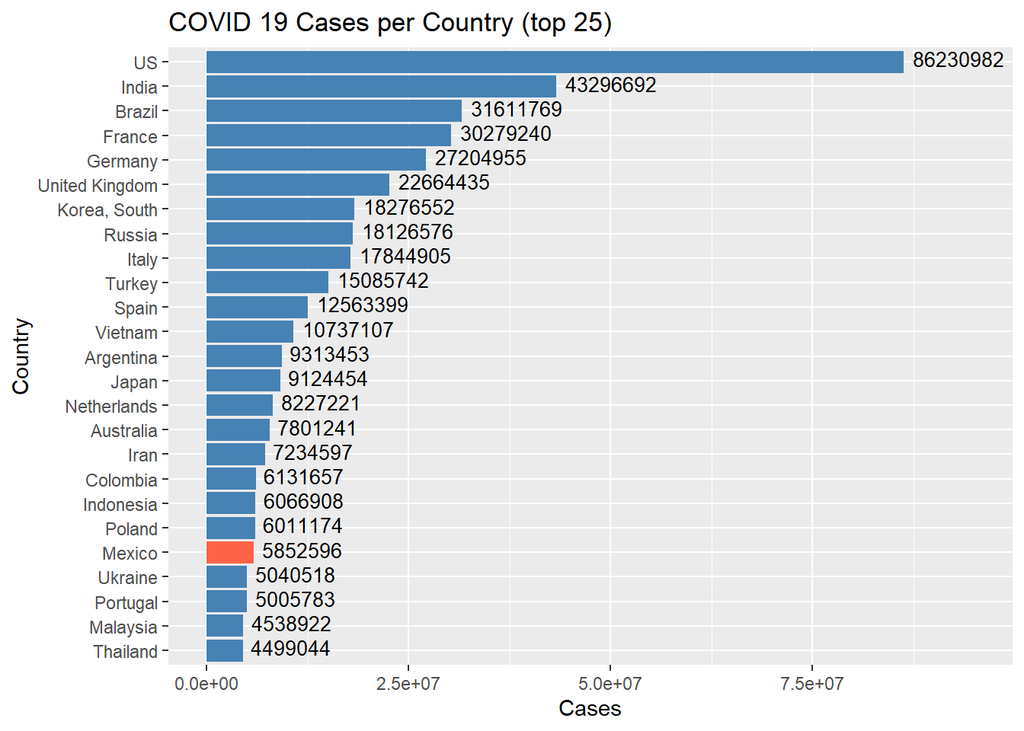

```r
global_by_country_totals <- global_by_country %>%
  group_by(Country_Region) %>%
  summarize(deaths = max(deaths), cases = max(cases), population = max(Population),
            cases_per_thou = 1000*cases/population, deaths_per_thou = 1000 * deaths / population) %>%
  filter(cases > 0, population > 0)

global_by_country_totals %>%
  slice_max(cases, n = 25) %>%
  mutate( ToHighlight = ifelse( Country_Region == "Mexico", "yes", "no" ) ) %>%
  ggplot(aes(x=reorder(Country_Region, cases), y=cases, fill=ToHighlight)) +
  geom_bar(stat="identity") +
  scale_fill_manual( values = c( "yes"="tomato", "no"="steelblue" ), guide = "none" ) +
  geom_text(aes(label=cases), vjust=0.3, hjust=-0.1, size=3.5)+
  ylim(0, 9.5e7)+
  ggtitle("COVID 19 Cases per Country (top 25)") +
  xlab("Country") +
  ylab("Cases") +
  coord_flip()
```

### Analysis 1

When sorting all countries according to then number of Covid cases, Mexico is positioned at the 21st place with a total of 5,852,596 registered patients. Given Mexico’s population of 128.9 million people, this is equivalent to 4.54% of the national population.

It is also worth noting that in proportion to the country with the most cases (US), Mexico has 1/15 th of the cases with a third of the population, but has a closer relation with the second place (India), with 1/7 th of the cases with a tenth of the population

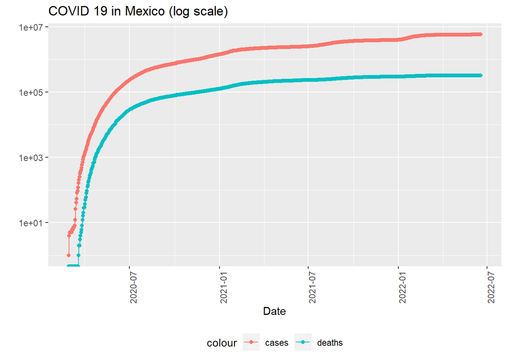

```r
Mexico <- global_by_country %>% filter(Country_Region == "Mexico")

Mexico %>%
  filter(cases > 0) %>%
  ggplot(aes(x = date, y = cases)) +
  geom_line(aes(color = "cases")) +
  geom_point(aes(color = "cases")) +
  geom_line(aes(y = deaths, color = "deaths")) +
  geom_point(aes(y = deaths, color = "deaths")) +
  scale_y_log10() +
  theme(legend.position = "bottom",
        axis.text.x = element_text(angle = 90)) +
  ggtitle("COVID 19 in Mexico (log scale)") +
  xlab("Date") +
  ylab("")
```

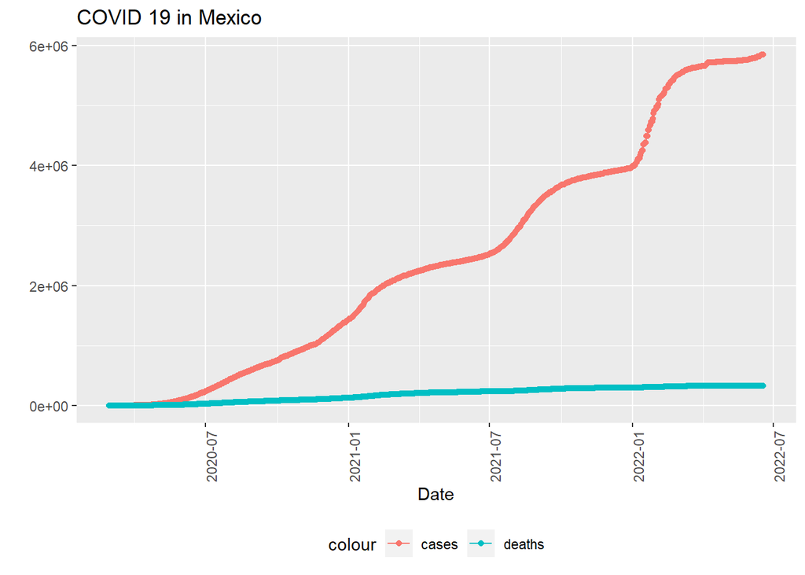

```r
Mexico %>%
  filter(cases > 0) %>%
  ggplot(aes(x = date, y = cases)) +
  geom_line(aes(color = "cases")) +
  geom_point(aes(color = "cases")) +
  geom_line(aes(y = deaths, color = "deaths")) +
  geom_point(aes(y = deaths, color = "deaths")) +
  theme(legend.position = "bottom",
        axis.text.x = element_text(angle = 90)) +
  ggtitle("COVID 19 in Mexico") +
  xlab("Date") +
  ylab("")
```

### Analisis 2

When taking the growth of cases and deaths in a logarithmic scale, it appears as if they have leveled off. However, if the same data is ploted in a linear scale, it becomes evident that the Covid 19 spread has not yet been stopped.

It is worth noting that only 5% of infected patients succumb to it, having a much slower growth rate than the Covid infection itself.

```r
Mexico <- Mexico %>%
  mutate(new_cases = cases - lag(cases), new_deaths = deaths - lag(deaths),
        cases_per_thou = 1000*cases/Population, deaths_per_thou = 1000 * deaths / Population,
        new_cases_per_thou = 1000*new_cases/Population, new_deaths_per_thou = 1000 * new_deaths / Population) %>%
  mutate(new_cases = ifelse(is.na(new_cases), 0, new_cases)) %>%
  mutate(new_deaths = ifelse(is.na(new_deaths), 0, new_deaths)) %>%
  mutate(new_cases_per_thou = ifelse(is.na(new_cases_per_thou), 0, new_cases_per_thou)) %>%
  mutate(new_deaths_per_thou = ifelse(is.na(new_deaths_per_thou), 0, new_deaths_per_thou))
```

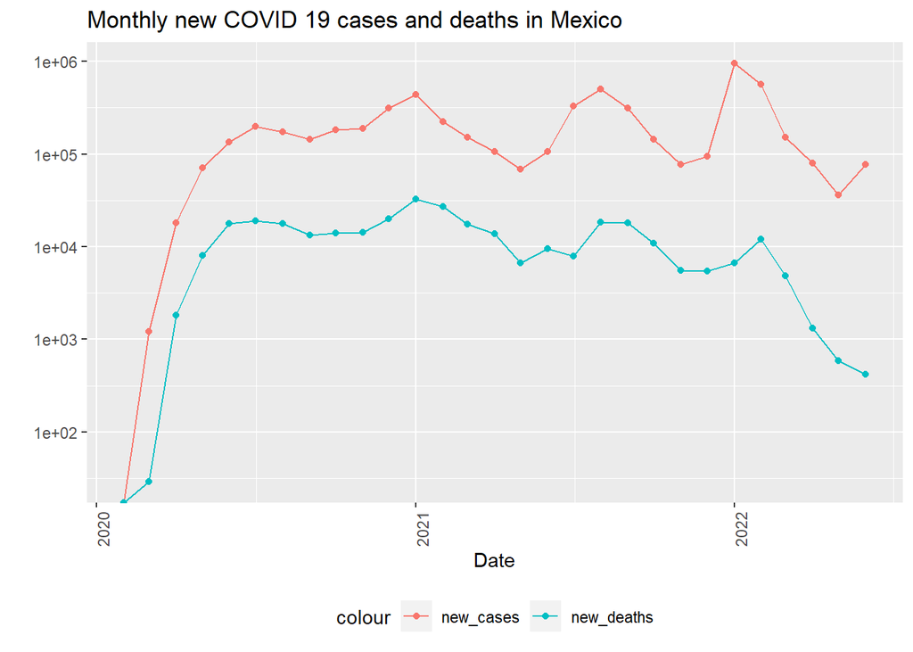

```r
monthly_cases <- Mexico %>%
  mutate(Month_Yr = format_ISO8601(date, precision = "ym")) %>%
  mutate(Month_Yr = ym(Month_Yr)) %>%
  group_by(Month_Yr) %>%
  summarize(deaths = max(deaths), cases = max(cases), population = max(Population),
            cases_per_thou = 1000*cases/population, deaths_per_thou = 1000 * deaths / population) %>%
  mutate(new_cases = cases - lag(cases), new_deaths = deaths - lag(deaths)) %>%
  mutate(new_cases = ifelse(is.na(new_cases), 0, new_cases)) %>%
  mutate(new_deaths = ifelse(is.na(new_deaths), 0, new_deaths)) %>%
  filter(cases > 0)

monthly_cases %>%
  ggplot(aes(x = Month_Yr, y = new_cases)) +
  geom_line(aes(color = "new_cases")) +
  geom_point(aes(color = "new_cases")) +
  geom_line(aes(y = new_deaths, color = "new_deaths")) +
  geom_point(aes(y = new_deaths, color = "new_deaths")) +
  scale_y_log10() +
  theme(legend.position = "bottom",
        axis.text.x = element_text(angle = 90)) +
  labs(title = "", y = NULL) +
  ggtitle("Monthly new COVID 19 cases and deaths in Mexico") +
  xlab("Date") +
  ylab("")
```